# U-shaped patterns in income growth

Use `sample_growth_tb` to examine the ratio of log growth over the first three years to log growth over the full six years for individuals whose 2014–2020 log growth exceeds a threshold. In relation to the predictions of subexponentiality, examine whether the ratio exhibits a U-shape, with concentrations near zero and one.

## 1 Data preparation and ratio construction

```r
library(tidyverse)
library(pins)
# Specify relative paths for the board, figure output directory, and plotting theme.
board <- board_folder("../income_board_replicate")
graph_dir <- "graph"
dir.create(graph_dir, recursive = TRUE, showWarnings = FALSE)
source("theme_ipsum_like.R")
theme_set(theme_ipsum())
```

**Definition of the ratio variable**

Load `sample_growth_tb` and calculate age `age` as the beginning year extracted from the period label minus the birth year in the first four characters of `birth_date`. For each period, select observations with beginning-of-period income of at least 4 million yen and beginning-of-period age 25–60. Both 2014–2017 (`g_17_14`) and 2014–2020 (`g_20_14`) start in 2014. Retain observations with finite growth rates in both periods in `ratio_tb`. Define the ratio as $r_{20,14}=g_{17,14}/g_{20,14}$.

```r
sample_growth_tb <- board |> pin_read("sample_growth_tb") |>
  mutate(age = as.numeric(str_c(20, str_sub(year,6,7))) - as.numeric(str_sub(birth_date, 1, 4))) |>
  filter(pre_income >= 4*10^6,
         age >= 25, age <= 60)

ratio_tb <- sample_growth_tb |>
  pivot_wider(id_cols = id, names_from = year, values_from = growth) |>
  filter(is.finite(g_17_14), is.finite(g_20_14)) |>
  mutate(r_20_14 = g_17_14 / g_20_14)
```

## 2 Ratio distributions by threshold

Exclude observations with ratios exactly equal to zero or one, and set threshold values $u$ from 0.1 to 2.8 in increments of 0.1. For each threshold, select individuals whose six-year growth satisfies $g_{20,14}>u$. Restrict the horizontal axis to −0.3–1.3 using `xlim()`.

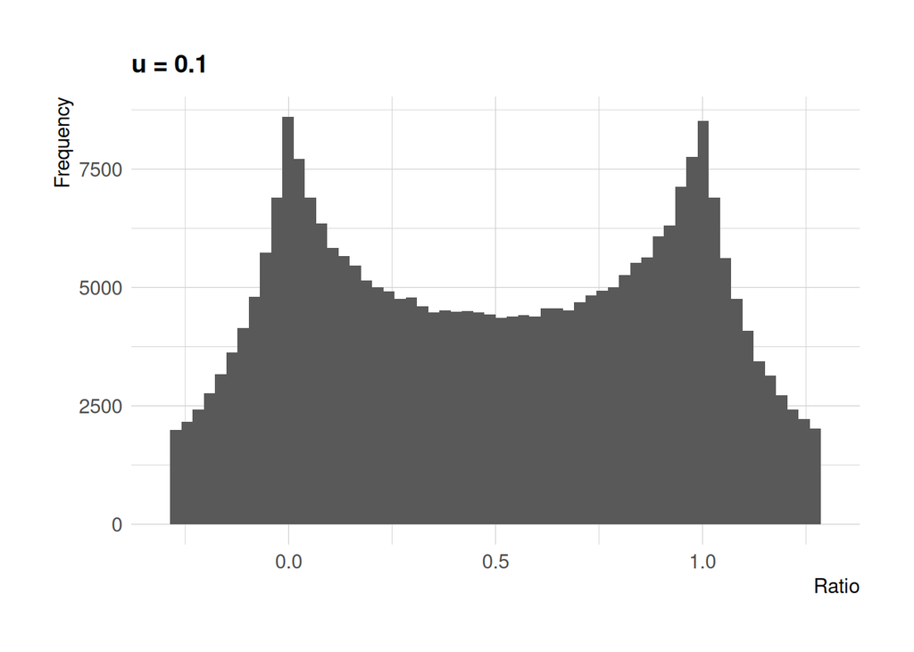

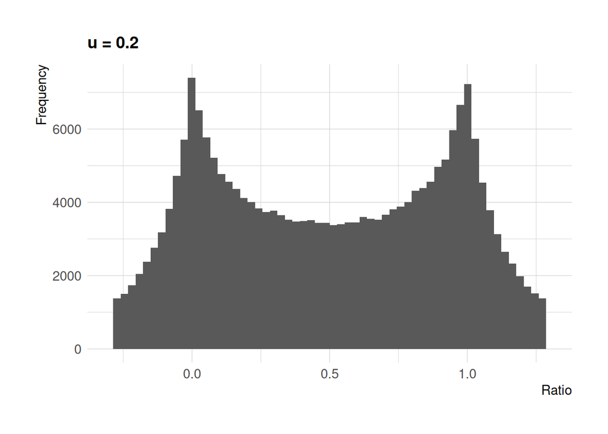

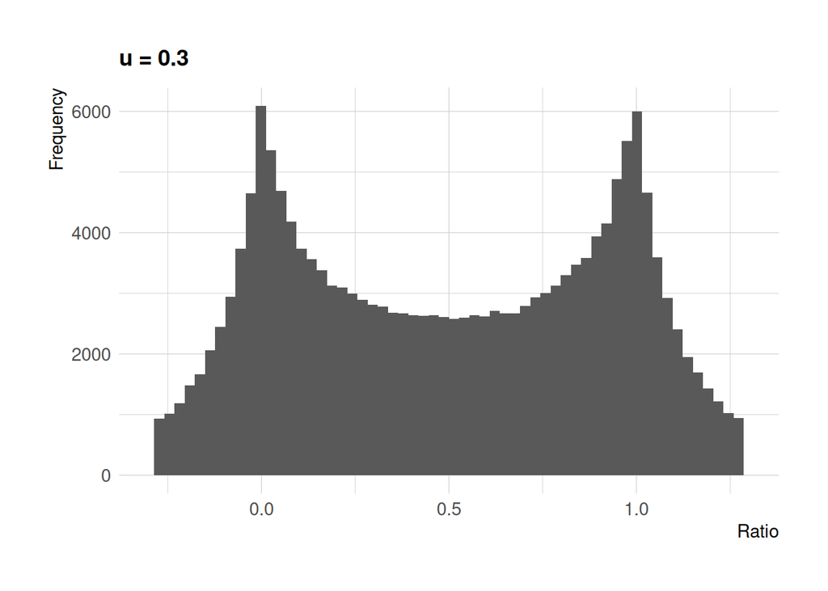

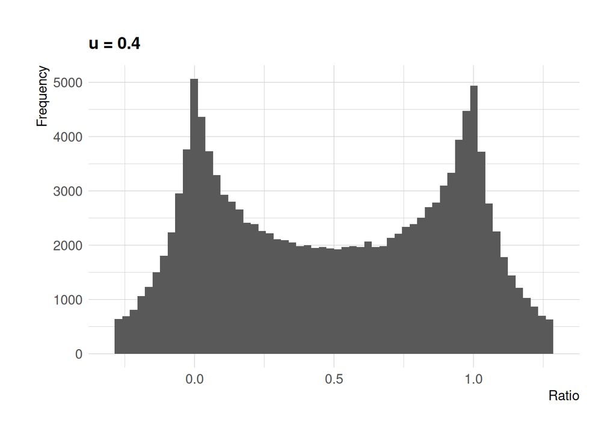

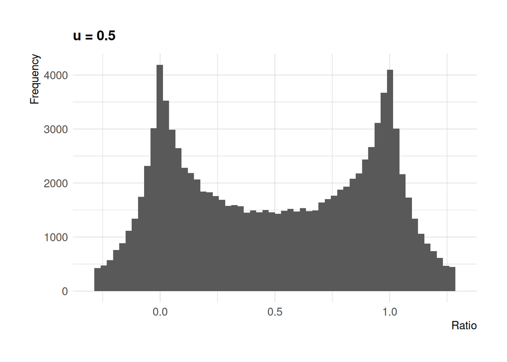

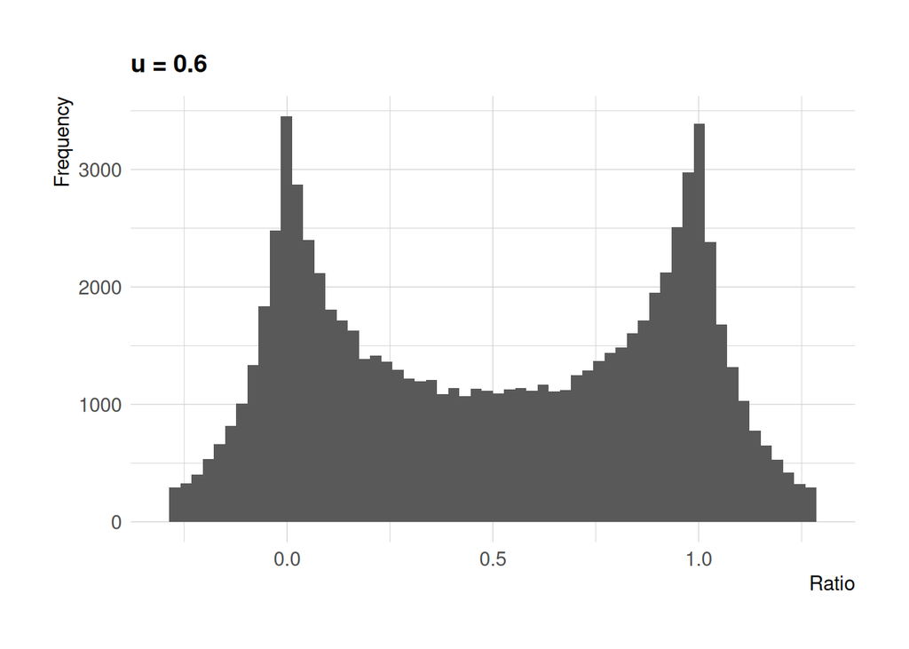

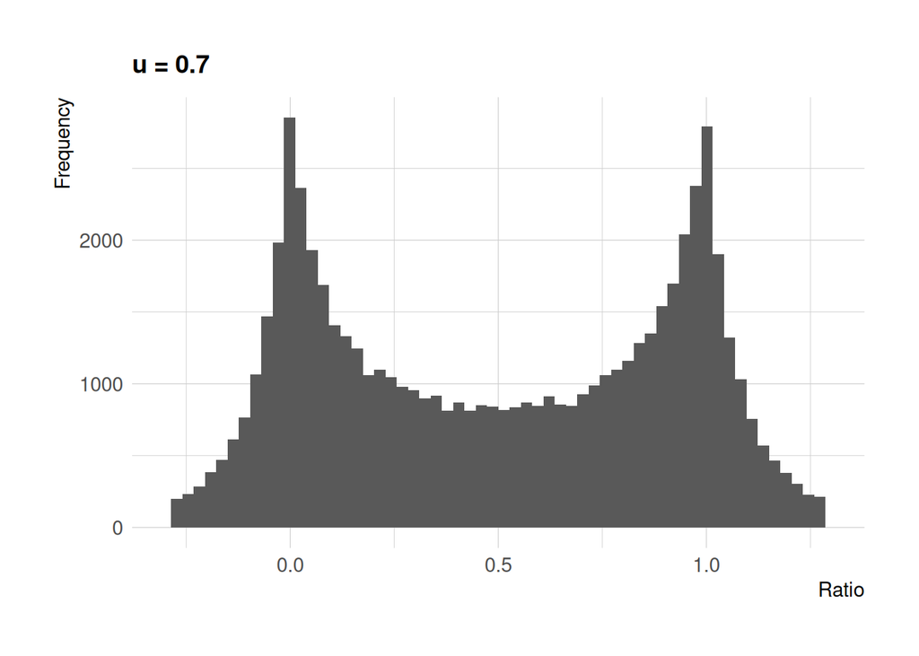

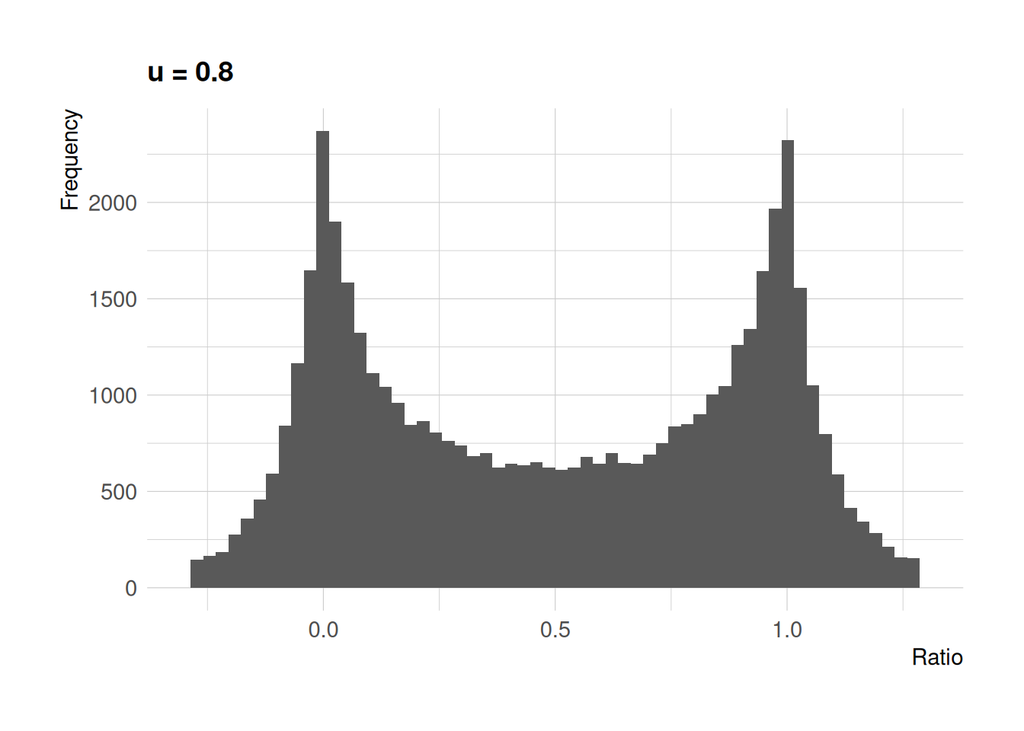

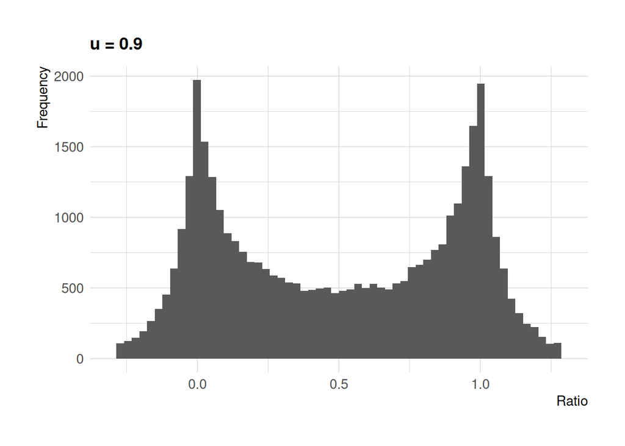

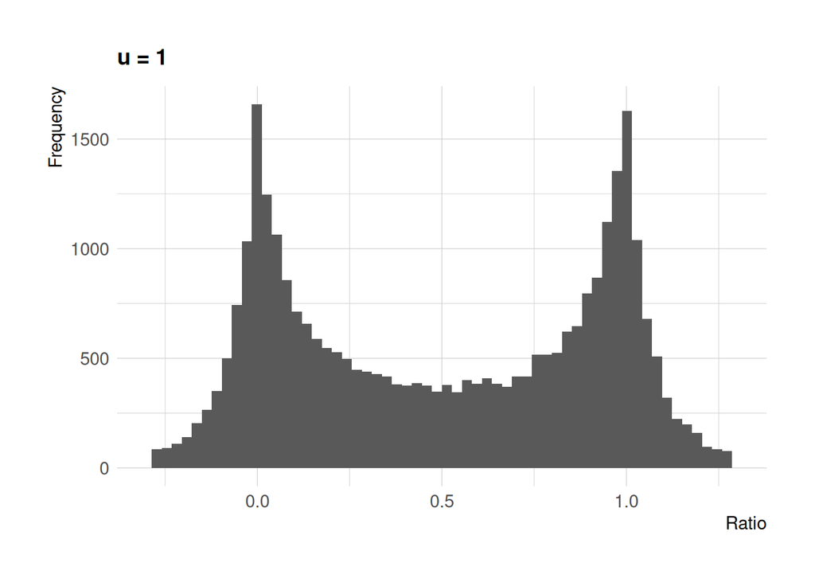

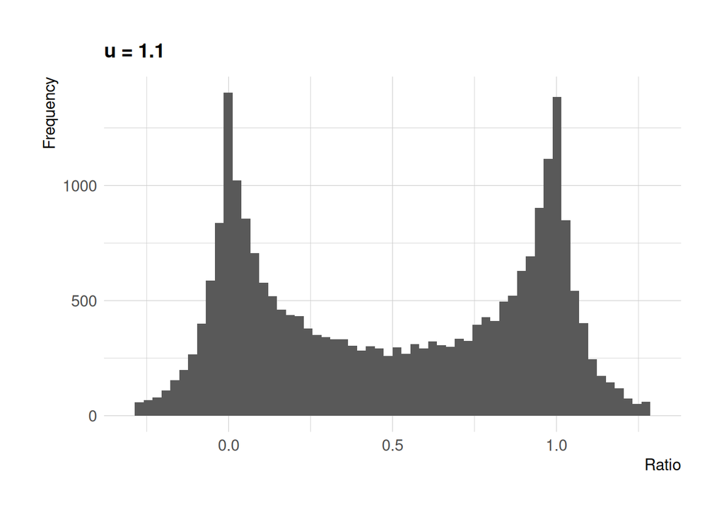

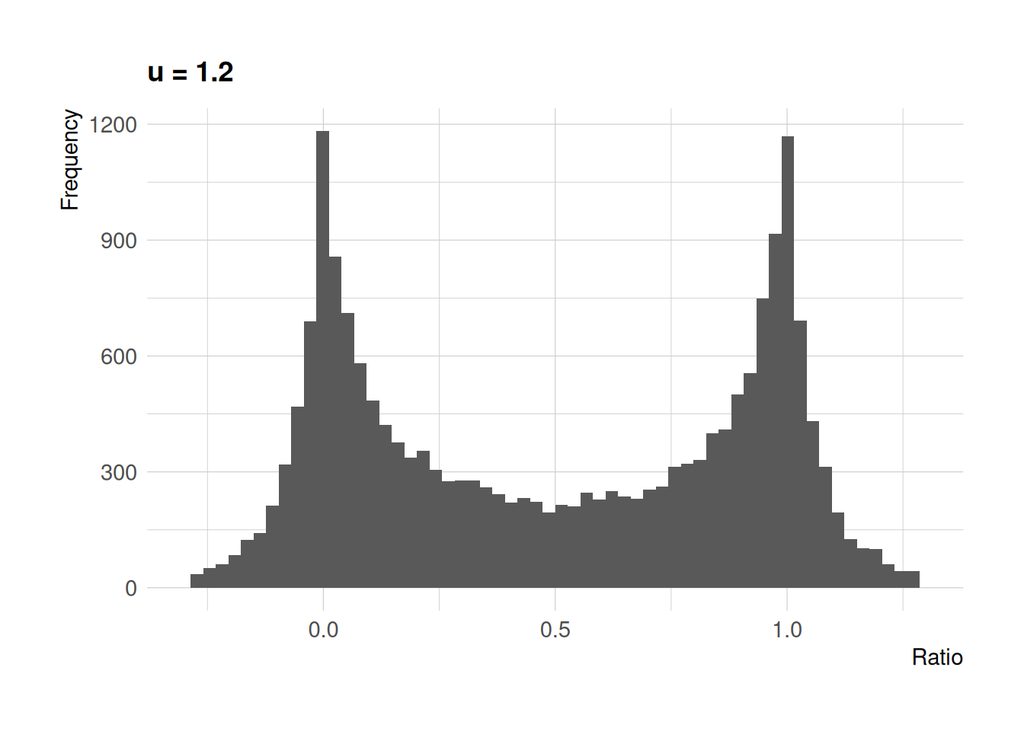

[16 more figures not shown]

```r
x_values <- seq(0.1, 2.8, by = 0.1)

plot_tb <- ratio_tb |>
  select(id, r_20_14, g_20_14) |>
  filter(r_20_14 != 0, r_20_14 != 1)

plots <- map(x_values, \(threshold) {
  plot_tb |>
    filter(g_20_14 > threshold) |>
    ggplot(aes(r_20_14)) +
    geom_histogram(bins = 60) +
    xlim(c(-0.3, 1.3)) +
    ggtitle(paste("u =", threshold)) +
    labs(x = "Ratio", y = "Frequency")
})

walk(plots, print)
walk2(plots, x_values, \(plot, threshold) {
  ggsave(
    filename = str_c("ratio_three_x_", threshold, "_income.png"),
    path = graph_dir,
    plot = plot
  )
})
```